# Predicting Student Performance from Survey Data

# Covariance - We will validiate above findings of no linear relationship by using covariance.

we will use variables as proved above in correlation (club,age,band,study,parents) compared with GPA . This will help us to understand the probabilistic behaviour/ joint behaviour of variables: Creating covariance matrix and pairs on entire data set

[output not shown]

# Pairwise comparison again:

Identifying / analysing any pairwise relationship for Total data set with 21 variables by drawing pair wise 1*1 plot to confirm that no significant relationship exists between any variables. ( ref code for details)

```r
##Identifying / analysing any pairwise relationship for Total data set with 21 variables by drawing pair wise 1*1 plot to confirm that no significant relationship exists between any variables.
pairs(cov(tab1,use = "pairwise.complete"))
##Another pair check for any relation

pairs(c,main = "Simple Scatterplot Matrix of covariance for GPA vs different variables", col = "red")
```

[output not shown]

Above pair wise relationship does not have significant covariance relationship between varables

Covariance for few variables - club/age/band/sport/GPA/Study/parents - As Covariance, unlike correlation, is not constrained to being between -1 and 1. But the sign will always be the same, and a covariance=0 has the exact same meaning as a correlation=0-no linear relationship. Drawing plots again for covariance which proves that there is low relationship between Study and GPA

```
##         age
## age 1.35065
```

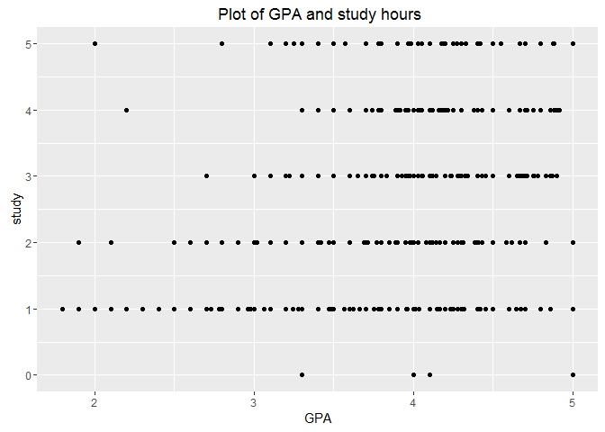

Howoever, only a very low value of study variable may have effect on GPA which has been proved earlier by logit model and be followed in machine learning.

Note - More details about plot/pairs for entire dataset in rmd code.

# Machine Learning

After the linear regression analysis and logit function prediction, we turned our attention to building a predictor of an at-risk student from the attributes in the table. Specifically we hope to use information about a student to predict if that student should be considered at-risk from an academic standpoint. For this part of the project, we are classifying an at-risk student as one that performs below one standard deviation from the mean.

There are several NA’s present in this data. For this segment of our project we tried to maintain as many data points as possible to help train our machines. The next block of code contains our analysis of the missing data in an attempt to determine the best method for replacing the NAs. After some study, we determined that the Mice library contained methods to help us impute the missing data based upon the enitre data set. This seemed like a better methodology than simply imputing the column means. The missing data seemed to be random and not systematic, and none of the missing data was frequent enough to warrant complete disposal of any data points.

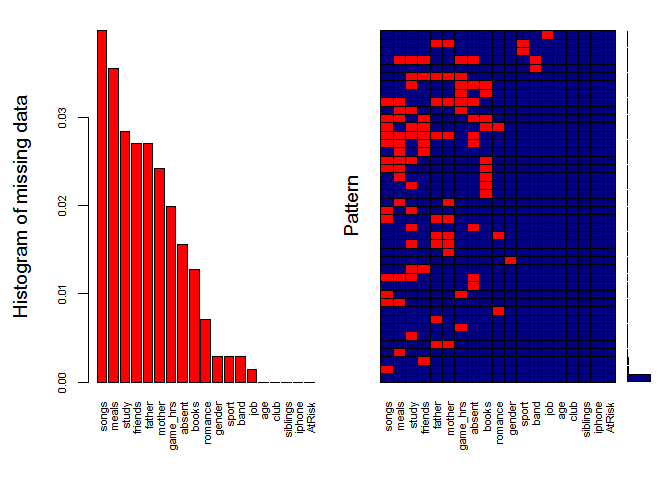

```
##
##  Variables sorted by number of missings:
##  Variable       Count
##     songs 0.039829303
##     meals 0.035561878
##     study 0.028449502
##   friends 0.027027027
##    father 0.027027027
##    mother 0.024182077
##  game_hrs 0.019914651
##    absent 0.015647226
##     books 0.012802276
##   romance 0.007112376
##    gender 0.002844950
##     sport 0.002844950
##      band 0.002844950
##       job 0.001422475
##       age 0.000000000
##      club 0.000000000
##  siblings 0.000000000
##    iphone 0.000000000
##    AtRisk 0.000000000
```

```r
#looks for visual patterns in missing data
#source code: [3]

#library(VIM)
aggr_plot <- aggr(x, col=c('navyblue','red'), numbers=FALSE, sortVars=TRUE, labels=names(data), cex.axis=.7, gap=3, ylab=c("Histogram of missing data","Pattern"))
```

```r
#impute missing data using mice package
# (Multiple Imputation by Chained Equations)

tempx <- mice(x,m=5,seed=123,print=FALSE)
#summary(tempx)
x <- complete(tempx,1)
```

Our next step was to normalize the data. In order to keep larger variables like age to skew our results, we converted all of the numerical data to their z-score equivalents. This should yield more accurate results in distance based comparisons.

```r
#normalize non-binary data to z-scores to prevent larger variables from having undo influence on differences

x$age <- scale(x$age,center = TRUE,scale = TRUE)
x$game_hrs <- scale(x$game_hrs,center = TRUE,scale = TRUE)
x$siblings <- scale(x$siblings,center = TRUE,scale = TRUE)
x$friends <- scale(x$friends,center = TRUE,scale = TRUE)
x$books <- scale(x$books,center = TRUE,scale = TRUE)
x$meals <- scale(x$meals,center = TRUE,scale = TRUE)
x$study <- scale(x$study,center = TRUE,scale = TRUE)
x$songs <- scale(x$songs,center = TRUE,scale = TRUE)
x$mother <- scale(x$mother,center = TRUE,scale = TRUE)
x$father <- scale(x$father,center = TRUE,scale = TRUE)
x$absent <- scale(x$absent,center = TRUE,scale = TRUE)

x <-as.data.frame(lapply(x,as.numeric))
x$AtRisk <- as.factor(x$AtRisk)
```

At this point we have prepared the data set and are ready to begin construction of a few machine learning models. Each model will require some tuning. The hope is to find the best model for this particular data set. First we need to create a training set and a test set:

```r
#create data split:  80% training, 20% test
inTrain <- createDataPartition(y = x$AtRisk,p=0.8)
train_set <- slice(x, inTrain$Resample1)
test_set <- slice(x, -inTrain$Resample1)
```

Our first model is k-nearest neighbors. We will create a model and check for our best guess at a good value for k using cross validation.

```r
#kNN classifier
#library(class)
risk_pred <- knn(train = train_set, test = test_set, cl = train_set$AtRisk, k=28)

#confusionMatrix(risk_pred, test_set$AtRisk)

kNN_acc <- postResample(risk_pred, test_set$AtRisk)
kNN_acc
```

```
##  Accuracy     Kappa
## 0.8500000 0.0743073
```

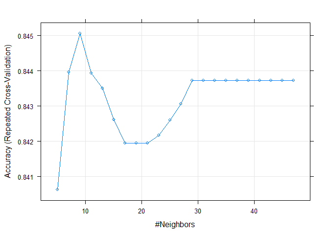

```r
#tune for best value of k.
ctrl <- trainControl(method="repeatedcv",repeats = 8)
knnFit <- train(AtRisk ~ ., data = train_set, method = "knn", trControl = ctrl, tuneLength = 22)
plot(knnFit)
```

#Estimate k value From this plot we can estimate a value of k and create our best kNN classifier:

```r
best_k = 8
risk_pred <- knn(train = train_set, test = test_set, cl = train_set$AtRisk, k=best_k)
confusionMatrix(risk_pred, test_set$AtRisk)
```

```
## Confusion Matrix and Statistics
##
##           Reference
## Prediction   0   1
##          0 118  18
##          1   0   4
##
##                Accuracy : 0.8714
##                  95% CI : (0.8044, 0.922)
##     No Information Rate : 0.8429
##     P-Value [Acc > NIR] : 0.2107
##
##                   Kappa : 0.2725
##  Mcnemar's Test P-Value : 6.151e-05
##
##             Sensitivity : 1.0000
##             Specificity : 0.1818
##          Pos Pred Value : 0.8676
##          Neg Pred Value : 1.0000
##              Prevalence : 0.8429
##          Detection Rate : 0.8429
##    Detection Prevalence : 0.9714
##       Balanced Accuracy : 0.5909
##
##        'Positive' Class : 0
##
```

```r
kNN_acc <- postResample(risk_pred, test_set$AtRisk)
#kNN_acc <- postResample(risk_probs, test_set$AtRisk)
kNN_acc
```

```
##  Accuracy     Kappa
## 0.8714286 0.2725173
```

```r
#attributes(kNN_acc)
```

```r
#knn_fit <- knn3(AtRisk~.,data = train_set , k = 18)
#f_hat <- predict(knn_fit, newdata = test_set)[,2]
#tab <- table(pred=round(f_hat), truth=test_set$AtRisk)
#confusionMatrix(tab)$tab
#confusionMatrix(tab)$overall["Accuracy"]
```

The next model we tried is a popular boosting algorithm called ‘adaboost.’ This method uses weighting to help strengthen good predictive features and weaken poor predictive ones. We then used adaboost in concert with rpart to try to find optimal decision trees, and base our model off these results. This process also gives us the ability to look at the importance of particular features to the model.

```r
#library(rpart)
#library(ada)
control <- rpart.control(cp = -1, maxdepth = 14,maxcompete = 1,xval = 0)

gen1 <- ada(AtRisk~., data = train_set, type = "gentle", control = control, iter = 100)
gen1 <- addtest(gen1, test_set[1:18],test_set$AtRisk)
summary(gen1)
```

```
## Call:
## ada(AtRisk ~ ., data = train_set, type = "gentle", control = control,
##     iter = 100)
##
## Loss: exponential Method: gentle   Iteration: 100
##
## Training Results
##
## Accuracy: 0.934 Kappa: 0.699
##
## Testing Results
##
## Accuracy: 0.871 Kappa: 0.311
```

```r
temp3 <- predict(gen1, newdata = test_set)
#temp3 <- as.vector(temp3[,1])

ada_acc <- postResample(temp3, test_set$AtRisk)
ada_acc
```

```
##  Accuracy     Kappa
## 0.8714286 0.3107221
```

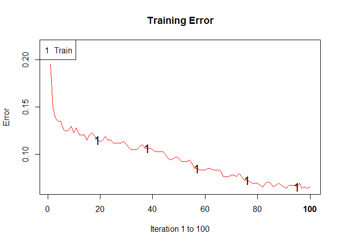

```r
plot(gen1)
```

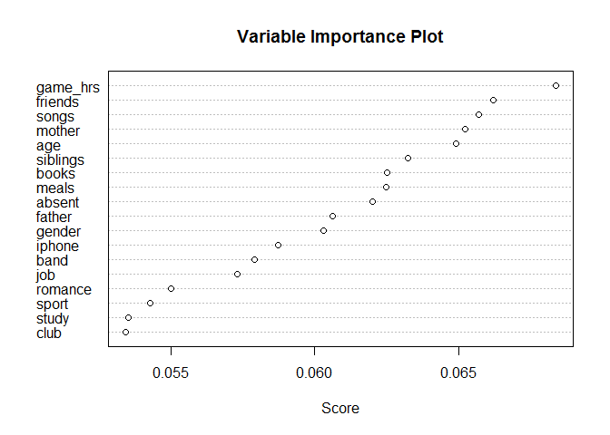

```r
varplot(gen1)
```

Another model we tried was a naive bayes classifier.

```r
###Naive Bayes classifier

bayes_model <- naiveBayes(train_set[1:18],train_set$AtRisk)
pred <- predict(bayes_model,test_set[1:18])

confusionMatrix(pred, test_set$AtRisk)
```

```
## Confusion Matrix and Statistics
##
##           Reference
## Prediction   0   1
##          0 107   8
##          1  11  14
##
##                Accuracy : 0.8643
##                  95% CI : (0.7962, 0.9163)
##     No Information Rate : 0.8429
##     P-Value [Acc > NIR] : 0.2869
##
##                   Kappa : 0.5146
##  Mcnemar's Test P-Value : 0.6464
##
##             Sensitivity : 0.9068
##             Specificity : 0.6364
##          Pos Pred Value : 0.9304
##          Neg Pred Value : 0.5600
##              Prevalence : 0.8429
##          Detection Rate : 0.7643
##    Detection Prevalence : 0.8214
##       Balanced Accuracy : 0.7716
##
##        'Positive' Class : 0
##
```

```r
bayes_acc <- postResample(pred, test_set$AtRisk)
bayes_acc
```

```
##  Accuracy     Kappa
## 0.8642857 0.5145985
```

We also tried a method based on a Support Vector Machine (SVM.) We were unable to improve the model through the automatic tuning process, but the model did yield good results.

```r
#Support vector Machine (SVM)
#library(e1071)
svm_model<- svm(AtRisk~., data=train_set, probability = TRUE, type="C-classification")
summary(svm_model)
```

```
##
## Call:
## svm(formula = AtRisk ~ ., data = train_set, probability = TRUE,
##     type = "C-classification")
##
##
## Parameters:
##    SVM-Type:  C-classification
##  SVM-Kernel:  radial
##        cost:  1
##       gamma:  0.05555556
##
## Number of Support Vectors:  296
##
##  ( 208 88 )
##
##
## Number of Classes:  2
##
## Levels:
##  0 1
```

```r
predicted <- predict(svm_model,test_set)
confusionMatrix(predicted, test_set$AtRisk)
```

```
## Confusion Matrix and Statistics
##
##           Reference
## Prediction   0   1
##          0 117  19
##          1   1   3
##
##                Accuracy : 0.8571
##                  95% CI : (0.788, 0.9105)
##     No Information Rate : 0.8429
##     P-Value [Acc > NIR] : 0.3727883
##
##                   Kappa : 0.1917
##  Mcnemar's Test P-Value : 0.0001439
##
##             Sensitivity : 0.9915
##             Specificity : 0.1364
##          Pos Pred Value : 0.8603
##          Neg Pred Value : 0.7500
##              Prevalence : 0.8429
##          Detection Rate : 0.8357
##    Detection Prevalence : 0.9714
##       Balanced Accuracy : 0.5639
##
##        'Positive' Class : 0
##
```

```r
svm_acc <- postResample(predicted, test_set$AtRisk)
svm_acc
```

```
##  Accuracy     Kappa
## 0.8571429 0.1916859
```

```r
###svm tuning (none of these improved the SVM-radial model)

#svmFit <- tune(svm, AtRisk~.,data = train_set)
```

Four different models now give us a picture of what we can expect from an accuracy perspective.

```r
#summary of accuracy
#library(knitr)
results <- data_frame(method = "kNN", Accuracy = kNN_acc[1])
results <- bind_rows(results,
                          data_frame(method="Naive Bayes",
                                     Accuracy = bayes_acc[1]))
results <- bind_rows(results,
                          data_frame(method="SVM",
                                     Accuracy = svm_acc[1]))
results <- bind_rows(results,
                          data_frame(method="adaBoost",
                                     Accuracy = ada_acc[1]))
options(digits = 3)
results %>% kable
```

| method | Accuracy |
| --- | --- |
| kNN | 0.871 |
| Naive Bayes | 0.864 |
| SVM | 0.857 |
| adaBoost | 0.871 |

Can we reduce our feature set and still get good results or better results? We attempted to apply some feature reduction techniques, and we performed some feature analysis using the mlbench library and also some random forest functions. The mlbench information was inconclusive, but we found that a few of the features seemed to be very important to the model.

```r
###Feature selection/reduction using kNN model
#library(mlbench)
#importance <- varImp(knnFit,scale=FALSE)
#print(importance)
#plot(importance)

#use a random forest to try and reduce features/lower overfit
#Code source: [4]
control <- rfeControl(functions=rfFuncs, method="cv", number=5)
results <- rfe(train_set[,1:18], train_set$AtRisk, sizes=c(1:18), rfeControl=control)
print(results)
```

```
##
## Recursive feature selection
##
## Outer resampling method: Cross-Validated (5 fold)
##
## Resampling performance over subset size:
##
##  Variables Accuracy  Kappa AccuracySD KappaSD Selected
##          1    0.844 0.0000    0.00411  0.0000
##          2    0.840 0.0503    0.01515  0.0776
##          3    0.845 0.0937    0.01824  0.1251
##          4    0.831 0.1245    0.02146  0.1365
##          5    0.828 0.1022    0.01985  0.0593
##          6    0.819 0.0612    0.02636  0.1174
##          7    0.817 0.0457    0.02239  0.0977
##          8    0.824 0.0726    0.02552  0.1105
##          9    0.822 0.1142    0.03313  0.1589
##         10    0.821 0.0575    0.03558  0.1001
##         11    0.830 0.0951    0.03161  0.1346
##         12    0.830 0.0768    0.03770  0.1397
##         13    0.830 0.0443    0.02641  0.1195
##         14    0.835 0.0647    0.01982  0.1138
##         15    0.842 0.0814    0.02240  0.1210
##         16    0.835 0.0757    0.01982  0.1334
##         17    0.846 0.1156    0.01801  0.0879        *
##         18    0.846 0.0993    0.01431  0.0904
##
## The top 5 variables (out of 17):
##    study, mother, father, club, game_hrs
```

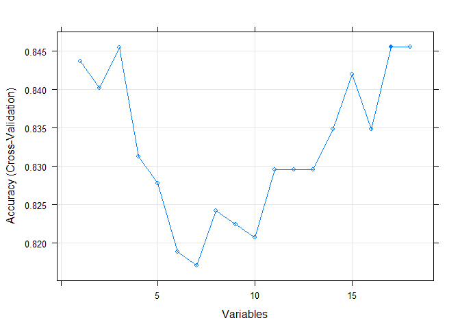

```r
plot(results, type=c("g", "o"))
```

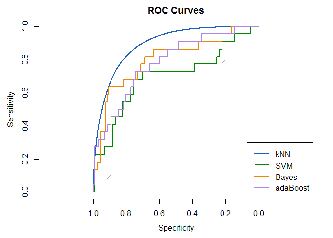

```r
risk_probs <- knn(train = train_set, test = test_set, cl = train_set$AtRisk, k=best_k, prob = TRUE)
temp <- attributes(risk_probs)[3]
roc_knn <- roc(test_set$AtRisk, temp$prob)
#plt <- plot(roc_knn)
knn_auc <- auc(roc_knn)

SVMpredicted <- predict(svm_model,test_set,probability = TRUE)
temp <- attributes(SVMpredicted)[4]
temp2 <- as.vector(temp$probabilities[,1])
roc_svm <- roc(test_set$AtRisk, temp2)
#plt <- plot(roc_svm)
svm_auc <- auc(roc_svm)

pred_probs <- predict(bayes_model,test_set[1:18],type = "raw")
temp2 <- as.vector(pred_probs[,1])
roc_bayes <- roc(test_set$AtRisk, temp2)
bayes_auc <- auc(roc_bayes)

temp3 <- predict(gen1, newdata = test_set , type = "probs")
temp3 <- as.vector(temp3[,1])
roc_ada <- roc(test_set$AtRisk, temp3)
ada_auc <- auc(roc_ada)

#Base Code Source: [5]

rocobj1 <- plot.roc(smooth(roc_knn), main="ROC Curves", col="#1c61b6")

rocobj2 <- lines.roc(roc_svm, col="#008600")

rocobj3 <- lines.roc(roc_bayes, col="#ef8600")

rocobj4 <- lines.roc(roc_ada, col="#ae86e3")

legend("bottomright", legend=c("kNN", "SVM", "Bayes", "adaBoost"), col=c("#1c61b6", "#008600","#ef8600","#ae86e3"), lwd=2)
```

The ROC Curves all yield similar results with the exception of our k-nearest neighbors model. This supports the idea that kNN is our best model, as we guessed from the accuracy scores above. The lack of granularity in the kNN model is likely due to the fixed number of neighbors, as this model is using that figure to calculate probabilites of class membership. We have appliede a smoother to kNN to make the comparison more clear.

```r
results <- data_frame(method = "kNN", AUC = knn_auc)
results <- bind_rows(results,
                          data_frame(method="Naive Bayes",
                                     AUC = bayes_auc))
results <- bind_rows(results,
                          data_frame(method="SVM",
                                     AUC = svm_auc))
results <- bind_rows(results,
                          data_frame(method="adaBoost",
                                     AUC = ada_auc))
options(digits = 3)
results %>% kable
```

| method | AUC |
| --- | --- |
| kNN | 0.870 |
| Naive Bayes | 0.801 |
| SVM | 0.696 |
| adaBoost | 0.781 |

It seems clear from this anaylsis that k-Nearest Neighbors (k=8) is the best classifier for at-risk students of the models we used. This makes some logical sense, as we are predicting the outcome of a student by the other students that are most similar, at least in terms of Euclidean distance. We also determined that even though many features were correlated, the models we used here needed most if not all of those features to make the best predictions. We can see from the above tests that macine learning can be used to help educators predict at-risk students from simple survey questions. The applications of this type of thinking have not yet been adopted yet by many learning institutions, but it seems clear that data science and machine learning can be utilized to help the educational process.

# Conclusion:

We can see that a student applying to a school with a few more hours of study, or if they are in a club, or if they are musicly inclined in band, would have higher odds of having a good GPA thus making them a better candidate. This could be one facet of predicting if a student would do well at their next academic institution.

With the Logit model we must remember that correlation is not causation. If a student is in a club then odds of their GPA going up increase by a factor of 7.483. That does not mean any student could join a club and their GPA would increase by that factor.

Further work would be to have an additional survey of more then one high school and include more questions about the type of club and the time they invest in it. The club beta seems to substantially increase a students odd of a good_GPA.

# Citations:

[1] http://statistics.ats.ucla.edu/stat/r/dae/logit.htm  
[2] http://www.montefiore.ulg.ac.be/~kvansteen/GBIO0009-1/ac20092010/Class8/Using%20R%20for%20linear%20regression.pdf  
[3] http://www.r-bloggers.com/imputing-missing-data-with-r-mice-package/ by Michy Alice on 10/04/2015  
[4] http://machinelearningmastery.com/feature-selection-with-the-caret-r-package/, Brownlee, Jason. 11/22/2014  
[5] Xavier Robin, Natacha Turck, Alexandre Hainard, Natalia Tiberti, Frédérique Lisacek, Jean-Charles Sanchez and Markus Müller (2011). pROC: an open-source package for R and S+ to analyze and compare ROC curves. BMC Bioinformatics, 12, p. 77. DOI: 10.1186/1471-2105-12-77.  
[6] http://www.r-bloggers.com/example-9-17-much-better-pairs-plots/  
[7] http://www.math.ucla.edu/~anderson/rw1001/library/base/html/cor.html  
[8] http://www.math.ucla.edu/~anderson/rw1001/library/base/html/pairs.html  
[9] https://stat.ethz.ch/R-manual/R-devel/library/graphics/html/pairs.html